# Writeup

Paul Thompson

10 December 2016

## Building the model for machine learning

To get started, lets take our training data and see what we can learn from what’s there.

```r
training <- read.csv('pml-training.csv', na.strings=c("#DIV/0!", "NA", ""))
dim(training)
```

```
## [1] 19622   160
```

```r
# Remove the columns that have no actual data in them
training<-training[,colSums(is.na(training)) == 0]
# Remove parts of the data that have no basis in the actual exercise (timestamp, user, etc)
training <- training[,-c(1:7)]
str(training)
```

```
## 'data.frame':    19622 obs. of  53 variables:
##  $ roll_belt           : num  1.41 1.41 1.42 1.48 1.48 1.45 1.42 1.42 1.43 1.45 ...
##  $ pitch_belt          : num  8.07 8.07 8.07 8.05 8.07 8.06 8.09 8.13 8.16 8.17 ...
##  $ yaw_belt            : num  -94.4 -94.4 -94.4 -94.4 -94.4 -94.4 -94.4 -94.4 -94.4 -94.4 ...
##  $ total_accel_belt    : int  3 3 3 3 3 3 3 3 3 3 ...
##  $ gyros_belt_x        : num  0 0.02 0 0.02 0.02 0.02 0.02 0.02 0.02 0.03 ...
##  $ gyros_belt_y        : num  0 0 0 0 0.02 0 0 0 0 0 ...
##  $ gyros_belt_z        : num  -0.02 -0.02 -0.02 -0.03 -0.02 -0.02 -0.02 -0.02 -0.02 0 ...
##  $ accel_belt_x        : int  -21 -22 -20 -22 -21 -21 -22 -22 -20 -21 ...
##  $ accel_belt_y        : int  4 4 5 3 2 4 3 4 2 4 ...
##  $ accel_belt_z        : int  22 22 23 21 24 21 21 21 24 22 ...
##  $ magnet_belt_x       : int  -3 -7 -2 -6 -6 0 -4 -2 1 -3 ...
##  $ magnet_belt_y       : int  599 608 600 604 600 603 599 603 602 609 ...
##  $ magnet_belt_z       : int  -313 -311 -305 -310 -302 -312 -311 -313 -312 -308 ...
##  $ roll_arm            : num  -128 -128 -128 -128 -128 -128 -128 -128 -128 -128 ...
```

[output cut: 39 more lines]

From all that data, we’re trying to classify the `classe` that comes from it. There are 5 levels, A, through E. Lets take a look at the distribution

```r
summary(training$classe)
```

```
##    A    B    C    D    E
## 5580 3797 3422 3216 3607
```

from that we can confirm we should have enough data to distinguish them all.

Lets try a decision tree as a first approach.

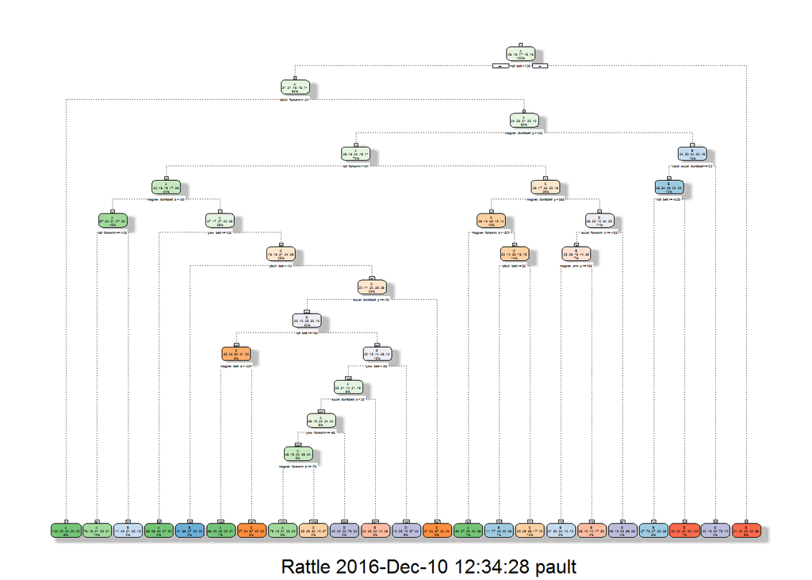

```r
set.seed(3042)
suppressWarnings(suppressMessages(library(caret)))
suppressWarnings(suppressMessages(library(dplyr)))
suppressWarnings(suppressMessages(library(rpart)))
suppressWarnings(suppressMessages(library(rattle)))
suppressWarnings(suppressMessages(library(randomForest)))
sets <- createDataPartition(y=training$classe, p=0.75, list=FALSE)
trainingSet <- training[sets,]
validation <- training[-sets,]
modFit <- rpart(classe ~ ., data=trainingSet, method="class")
fancyRpartPlot(modFit)
```

```r
predictionRpart <- predict(modFit, validation, type="class")
```

That’s a very complicated tree, and we can’t really visually tell what’s going on, so lets take a look at the results of a prediction with it.

```r
confusionMatrix(predictionRpart, validation$classe)
```

```
## Confusion Matrix and Statistics
##
##           Reference
## Prediction    A    B    C    D    E
##          A 1236  140   11   33   15
##          B   37  552   73   78   63
##          C   44  111  707  128  122
##          D   51   61   47  502   51
##          E   27   85   17   63  650
##
## Overall Statistics
##
##                Accuracy : 0.7437
##                  95% CI : (0.7312, 0.7559)
##     No Information Rate : 0.2845
##     P-Value [Acc > NIR] : < 2.2e-16
##
##                   Kappa : 0.6756
##  Mcnemar's Test P-Value : < 2.2e-16
##
## Statistics by Class:
##
##                      Class: A Class: B Class: C Class: D Class: E
## Sensitivity            0.8860   0.5817   0.8269   0.6244   0.7214
## Specificity            0.9433   0.9365   0.9000   0.9488   0.9520
## Pos Pred Value         0.8613   0.6874   0.6358   0.7051   0.7720
## Neg Pred Value         0.9542   0.9032   0.9610   0.9280   0.9382
## Prevalence             0.2845   0.1935   0.1743   0.1639   0.1837
## Detection Rate         0.2520   0.1126   0.1442   0.1024   0.1325
## Detection Prevalence   0.2926   0.1637   0.2268   0.1452   0.1717
## Balanced Accuracy      0.9147   0.7591   0.8634   0.7866   0.8367
```

As you can see, the accuracy is only at around 75% for the rpart’ed data. We can try an alernate strategy. Given that we got 75% for a single tree, a random forest algorithm is probably a good bet. With multiple trees we may be able to subsample in such a way that would capture the variability and account for it.

```r
modelRandomForest <- randomForest(classe ~ ., data=trainingSet, method="class")

predictRandomForest <- predict(modelRandomForest, validation, type="class")
confusionMatrix(predictRandomForest, validation$classe)
```

```
## Confusion Matrix and Statistics
##
##           Reference
## Prediction    A    B    C    D    E
##          A 1392    2    0    0    0
##          B    2  947    6    0    0
##          C    0    0  847    7    4
##          D    0    0    2  796    1
##          E    1    0    0    1  896
##
## Overall Statistics
##
##                Accuracy : 0.9947
##                  95% CI : (0.9922, 0.9965)
##     No Information Rate : 0.2845
##     P-Value [Acc > NIR] : < 2.2e-16
##
##                   Kappa : 0.9933
##  Mcnemar's Test P-Value : NA
##
## Statistics by Class:
##
##                      Class: A Class: B Class: C Class: D Class: E
## Sensitivity            0.9978   0.9979   0.9906   0.9900   0.9945
## Specificity            0.9994   0.9980   0.9973   0.9993   0.9995
## Pos Pred Value         0.9986   0.9916   0.9872   0.9962   0.9978
## Neg Pred Value         0.9991   0.9995   0.9980   0.9981   0.9988
## Prevalence             0.2845   0.1935   0.1743   0.1639   0.1837
## Detection Rate         0.2838   0.1931   0.1727   0.1623   0.1827
## Detection Prevalence   0.2843   0.1947   0.1750   0.1629   0.1831
## Balanced Accuracy      0.9986   0.9979   0.9940   0.9947   0.9970
```

This makes sense that it’s better. As random forest will combine many classification trees. In this example we’re using 500 decision trees rather than the 1 that got us to a 75% rating.

### Out of sample error rate

The out of sample error rate for this prediction is

```r
sum(predict(modelRandomForest, validation) != validation$classe) / nrow(validation) * 100
```

```
## [1] 0.5301794
```

### Prediction for the testing set

Lets use this prediction model on the test data

```r
testData <- read.csv('pml-testing.csv')
dim(testData)
```

```
## [1]  20 160
```

So, lets grab an answer for each of these rows

```r
predict(modelRandomForest, testData, type="class")
```

```
##  1  2  3  4  5  6  7  8  9 10 11 12 13 14 15 16 17 18 19 20
##  B  A  B  A  A  E  D  B  A  A  B  C  B  A  E  E  A  B  B  B
## Levels: A B C D E
```